# 量化分析：OPEN, SERV, GLD, TLT, TQQQ, TSLA, META, NVDA（2020-09-15 至 2025-09-15）

本笔记使用 Yahoo Finance 的真实日度数据，对指定资产进行：

- 收盘价与收益率分析
- 收益率相关性（皮尔逊相关系数热力图）
- 主成分分析（PCA）进行因子降维
- 波动率分析（标准差与滚动波动率）
- 风险调整收益（夏普比率，使用短端无风险利率近似）
- Beta 系数与市场基准（SPY）关系（静态与滚动）
- 策略模拟（等权重组合、最小方差组合、动量策略）
- 其他补充（回撤、滚动相关性）

说明：

- 默认使用 Yahoo Finance真实数据；若某标的在区间内数据缺失或退市，将在输出中明确标注，并在相应计算中自动剔除或以可用数据进行。
- 收益率基于“复权收盘价（Adj Close）”计算；展示价格时会标注。
- 分析区间：2020-09-15 至 2025-09-15。

```python
# 导入依赖与全局设置（每个导入均附中文注释）
import warnings  # 抑制不必要的警告
warnings.filterwarnings('ignore')

import pandas as pd  # 数据处理与时间序列分析
import numpy as np   # 数值计算
import yfinance as yf  # 从 Yahoo Finance 下载真实金融数据
import seaborn as sns  # 统计可视化与热力图
import matplotlib.pyplot as plt  # 通用绘图
from sklearn.decomposition import PCA  # 主成分分析
from sklearn.covariance import LedoitWolf  # 协方差收缩估计（稳健最小方差）
from scipy.stats import linregress  # 线性回归（估计Beta等）

# 让图像在Notebook内联显示
%matplotlib inline

# 统一绘图风格
sns.set(style='whitegrid', context='talk')
plt.rcParams['figure.figsize'] = (12, 6)
plt.rcParams['axes.titlesize'] = 14
plt.rcParams['axes.labelsize'] = 12

# 定义分析区间与标的
start_date = '2020-09-15'  # 起始日期
end_date = '2025-09-15'    # 结束日期

# 目标资产列表（用户指定）
TICKERS = ['OPEN', 'SERV', 'GLD', 'TLT', 'TQQQ', 'TSLA', 'META', 'NVDA']
# 市场基准与无风险近似（SPY：美股整体；^IRX：3M国债利率近似年化，无风险利率）
BENCHMARK = 'SPY'
RISK_FREE_PROXY = '^IRX'
```

```python
# 封装一个下载函数：下载多资产的复权收盘价
# 参数 tickers: 代码列表；start/end：日期范围
# 返回：DataFrame，索引为日期，列为各资产的复权收盘价

def download_adj_close(tickers, start, end):
    data = yf.download(tickers, start=start, end=end, auto_adjust=False, progress=False)['Adj Close']
    # 若仅一个ticker时，返回Series，这里统一转换为DataFrame
    if isinstance(data, pd.Series):
        data = data.to_frame()
    return data

# 下载主资产价格、基准与无风险近似
prices = download_adj_close(TICKERS, start_date, end_date)
benchmark_prices = download_adj_close([BENCHMARK], start_date, end_date)
risk_free_proxy = yf.download(RISK_FREE_PROXY, start=start_date, end=end_date, auto_adjust=False, progress=False)['Adj Close']

# 处理缺失数据：报告缺失并前向填充/剔除
missing_report = prices.isna().sum()
print('各标的缺失值数量:\n', missing_report)

# 前向填充后再后向填充，最大允许2天缺失以平滑（更严可改为0）
prices_ffill = prices.ffill(limit=2).bfill(limit=2)
benchmark_prices_ffill = benchmark_prices.ffill(limit=2).bfill(limit=2)

# 对于仍存在严重缺失的列（>10%），在后续分析中将剔除
valid_cols = prices_ffill.columns[prices_ffill.isna().mean() < 0.1]
prices_clean = prices_ffill[valid_cols]

print('可用于后续分析的标的（缺失<10%）：', list(valid_cols))

# 无风险利率：^IRX为年化百分比（近似），换算为日度（/100/252）
rf_daily = (risk_free_proxy / 100.0) / 252.0
rf_daily = rf_daily.reindex(prices_clean.index).ffill().bfill()

# 保存中间结果，供后续复用
prices_all = prices_clean.copy()
benchmark_all = benchmark_prices_ffill.copy()
```

```
各标的缺失值数量:
 Ticker
GLD       0
META      0
NVDA      0
OPEN      0
SERV    875
TLT       0
TQQQ      0
TSLA      0
dtype: int64
可用于后续分析的标的（缺失<10%）： ['GLD', 'META', 'NVDA', 'OPEN', 'TLT', 'TQQQ', 'TSLA']
```

```python
# 基础数据检查与清洗（标注缺失或不存在的代码）
# 说明：有的代码可能不存在或在区间内无数据（如更名、退市），这里做显式检查。

all_requested = set(TICKERS)
all_downloaded = set(prices.columns)
missing_tickers = sorted(list(all_requested - all_downloaded))
if missing_tickers:
    print('以下代码在Yahoo可能不存在或无法在该区间获取有效数据，将从分析中剔除：', missing_tickers)
else:
    print('所有请求的标的均已成功获取数据。')

# 将有效列覆盖TICKERS顺序（剔除缺失者）
TICKERS_VALID = [t for t in TICKERS if t in prices_all.columns]
prices_all = prices_all[TICKERS_VALID]
print('用于分析的有效标的：', TICKERS_VALID)

# 与基准对齐索引
benchmark_all = benchmark_all.reindex(prices_all.index).ffill().bfill()
```

```
所有请求的标的均已成功获取数据。
用于分析的有效标的： ['OPEN', 'GLD', 'TLT', 'TQQQ', 'TSLA', 'META', 'NVDA']
```

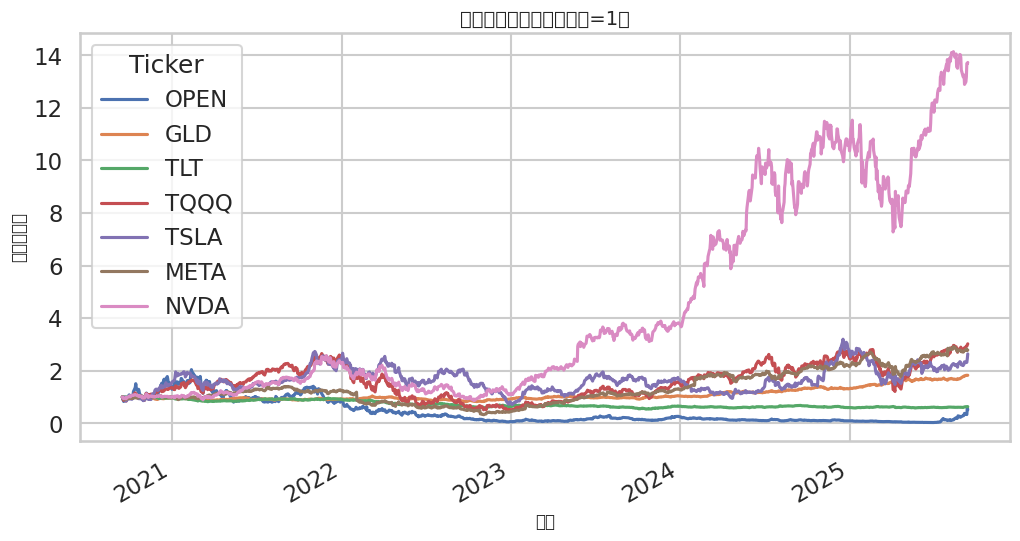

```
日度收益率描述性统计：
            mean       std       min       max
Ticker
OPEN    0.001906  0.072012 -0.263267  0.795222
GLD     0.000526  0.009504 -0.044271  0.036991
TLT    -0.000311  0.010206 -0.034183  0.038473
TQQQ    0.001809  0.043060 -0.183101  0.352442
TSLA    0.001520  0.038744 -0.154262  0.226900
META    0.001200  0.027515 -0.263901  0.232824
NVDA    0.002628  0.032954 -0.169682  0.243696
```

```python
# 计算日收益率、对数收益率，并绘制标准化价格走势
# 收益率说明：使用复权收盘价的简单收益率 r_t = P_t / P_{t-1} - 1；对数收益率 ln(P_t / P_{t-1})

# 计算简单收益率与对数收益率
returns = prices_all.pct_change().dropna()
log_returns = np.log(prices_all).diff().dropna()

# 归一化价格（以起始值=1），用于多资产同图比较
norm_prices = prices_all / prices_all.iloc[0]

# 绘制：标准化价格随时间的走势
ax = norm_prices.plot(title='标准化复权收盘价（起始=1）')
ax.set_xlabel('日期')
ax.set_ylabel('标准化价格')
plt.show()

# 简要统计描述（收益率）
print('日度收益率描述性统计：')
print(returns.describe().T[['mean','std','min','max']])
```

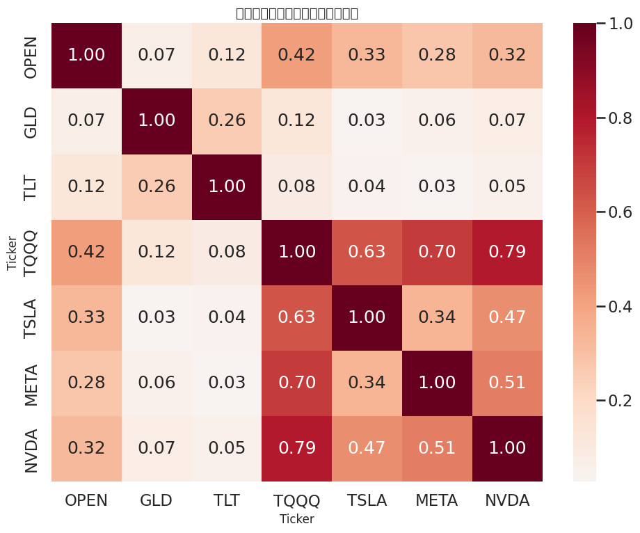

```python
# 相关性分析：皮尔逊相关系数与热力图
# 计算收益率之间的相关性矩阵，并绘制热力图

corr_matrix = returns.corr(method='pearson')
plt.figure(figsize=(10, 8))
sns.heatmap(corr_matrix, annot=True, fmt='.2f', cmap='RdBu_r', center=0)
plt.title('日度收益率皮尔逊相关系数热力图')
plt.tight_layout()
plt.show()

# 将相关性矩阵保存
corr_matrix.to_csv('/workspace/outputs/corr_matrix.csv')
```

```
各主成分的解释方差比： [0.6098 0.235  0.0792 0.0405 0.0177 0.0111]
累计解释方差比： [0.6098 0.8448 0.924  0.9645 0.9822 0.9933]
```

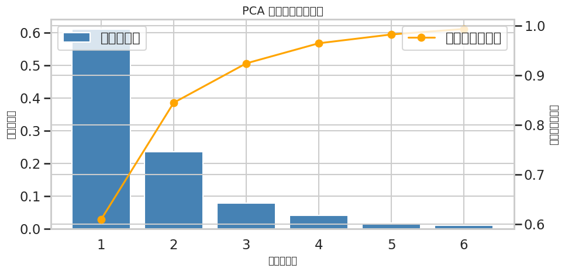

```
主成分载荷（前几列）：
             PC1       PC2       PC3       PC4       PC5       PC6
Ticker
OPEN    0.825487  0.563706 -0.011156 -0.006895 -0.021238 -0.011776
GLD     0.011112 -0.007858 -0.019194 -0.005419  0.172582  0.566295
TLT     0.015470  0.006221 -0.003916 -0.009702  0.147430  0.793699
TQQQ    0.387765 -0.548897 -0.228273  0.056716  0.681074 -0.164439
TSLA    0.277483 -0.394680  0.851885  0.071678 -0.183324  0.049751
```

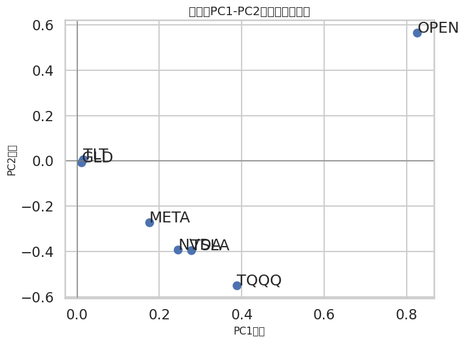

```python
# 主成分分析（PCA）：因子降维与解释方差
# 使用收益率做PCA，先对列做去均值（可选标准化，这里直接使用收益率）

# 去除含缺失的行
returns_pca = returns.dropna(how='any').copy()

# 拟合PCA（成分数不超过资产数）
pca = PCA(n_components=min(returns_pca.shape[1], 6), random_state=42)
pca_fit = pca.fit(returns_pca)

# 解释方差比
explained = pca.explained_variance_ratio_
print('各主成分的解释方差比：', np.round(explained, 4))
print('累计解释方差比：', np.round(np.cumsum(explained), 4))

# 可视化：解释方差比柱状图与累计曲线
fig, ax1 = plt.subplots(figsize=(10,5))
components = np.arange(1, len(explained) + 1)
ax1.bar(components, explained, color='steelblue', label='解释方差比')
ax1.set_xlabel('主成分编号')
ax1.set_ylabel('解释方差比')
ax1.set_title('PCA 解释方差比与累计')
ax2 = ax1.twinx()
ax2.plot(components, np.cumsum(explained), color='orange', marker='o', label='累计解释方差比')
ax2.set_ylabel('累计解释方差比')
ax1.legend(loc='upper left')
ax2.legend(loc='upper right')
plt.tight_layout()
plt.show()

# 主成分载荷（每个资产在各主成分上的权重）
loadings = pd.DataFrame(pca.components_.T, index=returns_pca.columns, columns=[f'PC{i}' for i in range(1, len(explained)+1)])
print('主成分载荷（前几列）：')
print(loadings.head())

# 可视化：前两个主成分载荷的散点图（风格图）
plt.figure(figsize=(8,6))
plt.scatter(loadings['PC1'], loadings['PC2'])
for asset, row in loadings.iterrows():
    plt.annotate(asset, (row['PC1'], row['PC2']))
plt.axhline(0, color='gray', lw=1)
plt.axvline(0, color='gray', lw=1)
plt.title('资产在PC1-PC2空间的载荷分布')
plt.xlabel('PC1载荷')
plt.ylabel('PC2载荷')
plt.tight_layout()
plt.show()
```

```
年化波动率（按日度std年化）：
 Ticker
OPEN    1.143158
TQQQ    0.683559
TSLA    0.615042
NVDA    0.523126
META    0.436792
TLT     0.162013
GLD     0.150876
dtype: float64
```

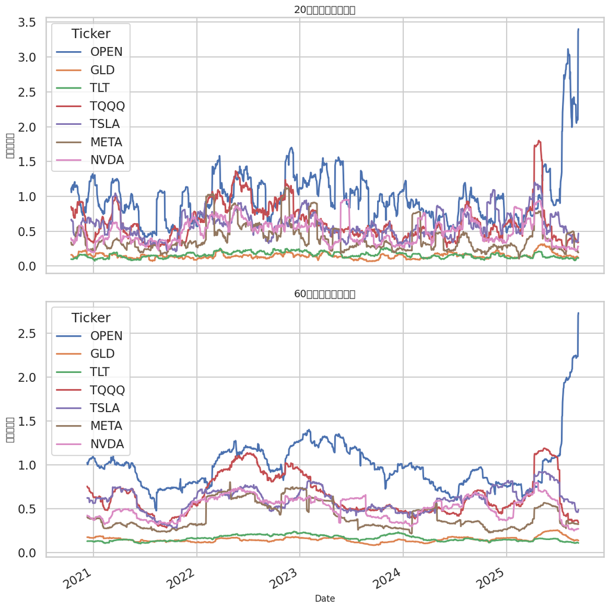

```python
# 波动率分析：标准差与滚动波动率
# 年化波动率 ≈ 日度标准差 * sqrt(252)

annualized_vol = returns.std() * np.sqrt(252)
print('年化波动率（按日度std年化）：\n', annualized_vol.sort_values(ascending=False))

# 计算滚动波动率（如20日、60日），并绘制
rolling_windows = [20, 60]
fig, axes = plt.subplots(len(rolling_windows), 1, figsize=(12, 6*len(rolling_windows)), sharex=True)
if len(rolling_windows) == 1:
    axes = [axes]
for ax, w in zip(axes, rolling_windows):
    rolling_vol = returns.rolling(window=w).std() * np.sqrt(252)
    rolling_vol.plot(ax=ax, title=f'{w}日滚动年化波动率')
    ax.set_ylabel('年化波动率')
plt.tight_layout()
plt.show()
```

```
年化收益(%)：
 Ticker
OPEN    48.02
GLD     13.27
TLT     -7.83
TQQQ    45.59
TSLA    38.30
META    30.25
NVDA    66.23
dtype: float64
年化波动率(%)：
 Ticker
OPEN    114.32
GLD      15.09
TLT      16.20
TQQQ     68.36
TSLA     61.50
META     43.68
NVDA     52.31
dtype: float64
夏普比率：
 Ticker
GLD    NaN
META   NaN
NVDA   NaN
OPEN   NaN
TLT    NaN
TQQQ   NaN
TSLA   NaN
^IRX   NaN
dtype: float64
```

[figure not shown]

```python
# 夏普比率：使用日度数据年化（252天），无风险利率来自^IRX（若缺失则置0）
# 夏普 = (年化收益 - 年化无风险) / 年化波动率

# 计算资产与基准的日度超额收益
rf_daily_aligned = rf_daily.reindex(returns.index).fillna(0.0)
excess_returns = returns.sub(rf_daily_aligned, axis=0)

# 年化收益（简单近似）：mean * 252； 年化波动率：std * sqrt(252)
ann_return = returns.mean() * 252
ann_vol = returns.std() * np.sqrt(252)
ann_rf = rf_daily_aligned.mean() * 252

sharpe = (ann_return - ann_rf) / ann_vol

print('年化收益(%)：\n', (ann_return*100).round(2))
print('年化波动率(%)：\n', (ann_vol*100).round(2))
print('夏普比率：\n', sharpe.round(2))

# 可视化：夏普比率柱状图
plt.figure(figsize=(10,6))
sharpe.sort_values(ascending=False).plot(kind='bar', color='teal', title='夏普比率（年化）')
plt.ylabel('Sharpe Ratio')
plt.tight_layout()
plt.show()
```

```
静态Beta（相对于SPY）：
 TQQQ    3.70
OPEN    2.58
NVDA    2.08
TSLA    1.97
META    1.58
GLD     0.11
TLT     0.05
dtype: float64
```

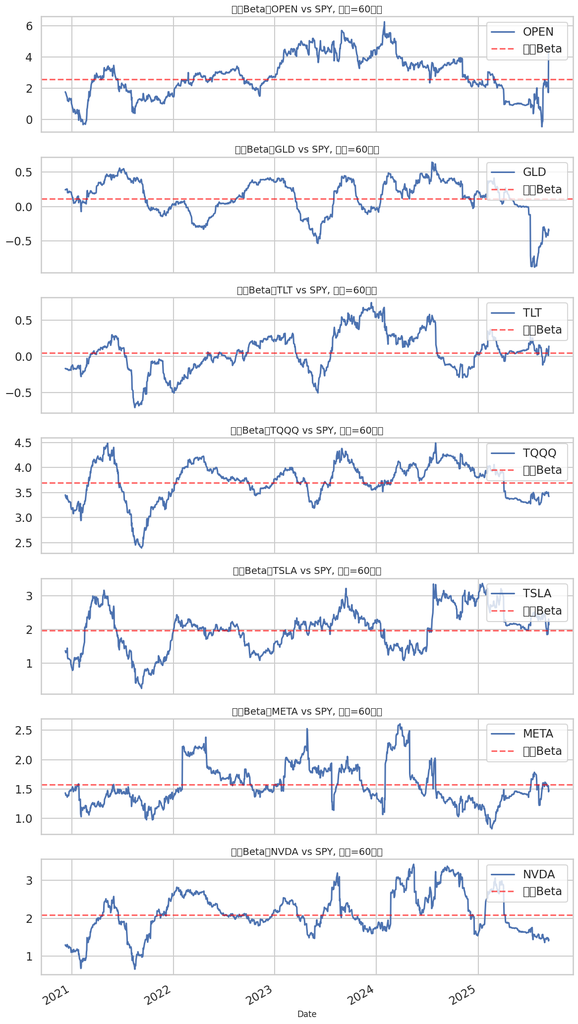

```python
# Beta 系数：相对于SPY（市场基准）
# 方法1：静态Beta（全样本线性回归）；方法2：滚动Beta（例如60日窗口）

# 计算基准日收益率
benchmark_returns = benchmark_all.pct_change().dropna()
benchmark_returns = benchmark_returns.iloc[:, 0]  # 转为Series（SPY）

# 对齐资产与基准的日期
aligned = returns.join(benchmark_returns.to_frame('SPY'), how='inner')
R = aligned[TICKERS_VALID]
M = aligned['SPY']

# 静态Beta估计（线性回归：R_i = alpha + beta * M + eps）
static_beta = {}
for col in R.columns:
    valid = R[col].dropna().index.intersection(M.dropna().index)
    slope, intercept, r_value, p_value, std_err = linregress(M.loc[valid], R[col].loc[valid])
    static_beta[col] = slope

static_beta = pd.Series(static_beta)
print('静态Beta（相对于SPY）：\n', static_beta.sort_values(ascending=False).round(2))

# 滚动Beta（60日窗口）：beta_t = Cov(R_i, M) / Var(M)
window = 60
rolling_beta = pd.DataFrame(index=R.index, columns=R.columns, dtype=float)
var_m = M.rolling(window).var()
for col in R.columns:
    cov_im = R[col].rolling(window).cov(M)
    rolling_beta[col] = cov_im / var_m

# 可视化：滚动Beta
fig, axes = plt.subplots(len(TICKERS_VALID), 1, figsize=(12, 3*len(TICKERS_VALID)), sharex=True)
if len(TICKERS_VALID) == 1:
    axes = [axes]
for ax, col in zip(axes, TICKERS_VALID):
    rolling_beta[col].plot(ax=ax, title=f'滚动Beta（{col} vs SPY, 窗口={window}日）')
    ax.axhline(static_beta[col], color='red', linestyle='--', alpha=0.6, label='静态Beta')
    ax.legend(loc='upper right')
plt.tight_layout()
plt.show()
```

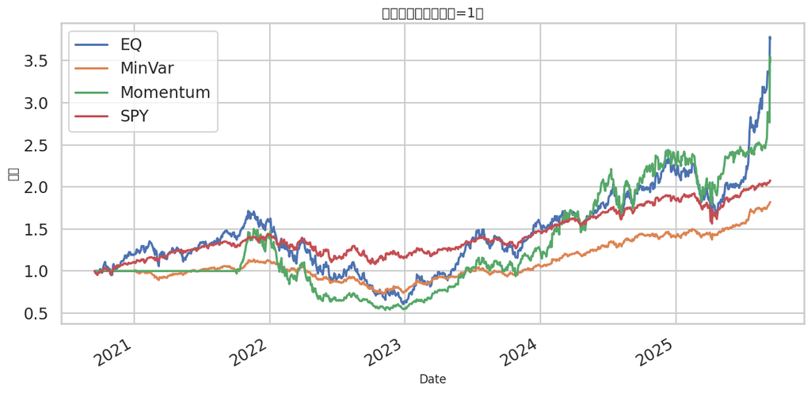

```
策略绩效摘要：
          AnnReturn    AnnVol                                  Sharpe     MaxDD
EQ        0.335296  0.372176  Ticker
^IRX    0.820467
dtype: float64 -0.646497
MinVar    0.130838  0.143762  Ticker
^IRX    0.701859
dtype: float64 -0.356836
Momentum  0.323431  0.383318  Ticker
^IRX    0.765667
dtype: float64 -0.642458
SPY        0.16274   0.17365  Ticker
^IRX    0.764777
dtype: float64 -0.244964
```

```python
# 策略模拟：等权重、最小方差、动量策略
# - 等权重：每期持有等权重，月度再平衡。
# - 最小方差：使用Ledoit-Wolf收缩协方差估计，最小方差权重（约束权重之和=1，非负投影）。
# - 动量：过去252个交易日的动量排名，买入前N只（如3只），月度调仓。

from datetime import datetime

# 月末重采样（调仓点）
rebalance_dates = returns.resample('M').last().index

# 1) 等权重组合（每月初等权再平衡）
weights_eq = pd.DataFrame(0.0, index=rebalance_dates, columns=TICKERS_VALID)
weights_eq.loc[:, :] = 1.0 / len(TICKERS_VALID)

# 将权重向前填充到当月每日
w_eq_daily = weights_eq.reindex(returns.index, method='ffill').fillna(method='ffill')
port_eq = (w_eq_daily * returns).sum(axis=1)

# 2) 最小方差组合（每月用过去60日协方差估计）
lookback_mv = 60
weights_mv = pd.DataFrame(0.0, index=rebalance_dates, columns=TICKERS_VALID)
for d in rebalance_dates:
    window_returns = returns.loc[returns.index <= d].tail(lookback_mv)
    if window_returns.shape[0] < lookback_mv:
        continue
    # Ledoit-Wolf协方差估计
    lw = LedoitWolf().fit(window_returns.values)
    cov = lw.covariance_
    # 最小方差权重闭式解并投影到非负
    ones = np.ones((cov.shape[0], 1))
    inv_cov = np.linalg.pinv(cov)
    raw_w = inv_cov @ ones
    raw_w = raw_w / (ones.T @ inv_cov @ ones)
    w = np.maximum(raw_w.flatten(), 0)
    w = w / w.sum() if w.sum() > 0 else np.ones_like(w)/len(w)
    weights_mv.loc[d, :] = w

w_mv_daily = weights_mv.reindex(returns.index, method='ffill').fillna(method='ffill')
port_mv = (w_mv_daily * returns).sum(axis=1)

# 3) 动量策略：过去252日累计收益，选前3只，月度换仓
lookback_mom = 252
top_n = 3
weights_mom = pd.DataFrame(0.0, index=rebalance_dates, columns=TICKERS_VALID)
for d in rebalance_dates:
    window_returns = returns.loc[:d].tail(lookback_mom)
    if window_returns.shape[0] < lookback_mom:
        continue
    cumret = (1 + window_returns).prod() - 1
    winners = cumret.sort_values(ascending=False).head(top_n).index
    weights_mom.loc[d, winners] = 1.0 / top_n

w_mom_daily = weights_mom.reindex(returns.index, method='ffill').fillna(0.0)
port_mom = (w_mom_daily * returns).sum(axis=1)

# 汇总组合净值并可视化
portfolio_nav = pd.DataFrame({
    'EQ': (1 + port_eq).cumprod(),
    'MinVar': (1 + port_mv).cumprod(),
    'Momentum': (1 + port_mom).cumprod(),
    'SPY': (1 + benchmark_returns.reindex(returns.index, method='ffill')).cumprod()
}, index=returns.index)

ax = portfolio_nav.plot(title='策略净值对比（起始=1）')
ax.set_ylabel('净值')
plt.tight_layout()
plt.show()

# 输出策略绩效（年化收益、波动、夏普、最大回撤）
def max_drawdown(nav_series: pd.Series) -> float:
    cummax = nav_series.cummax()
    dd = nav_series / cummax - 1
    return dd.min()

perf = {}
for name, nav in portfolio_nav.items():
    ret = nav.pct_change().dropna()
    ann_ret = ret.mean() * 252
    ann_vol = ret.std() * np.sqrt(252)
    sharpe_p = (ann_ret - ann_rf) / (ann_vol + 1e-9)
    mdd = max_drawdown(nav)
    perf[name] = {
        'AnnReturn': ann_ret,
        'AnnVol': ann_vol,
        'Sharpe': sharpe_p,
        'MaxDD': mdd,
    }

perf_df = pd.DataFrame(perf).T
print('策略绩效摘要：\n', perf_df.round(3))
```

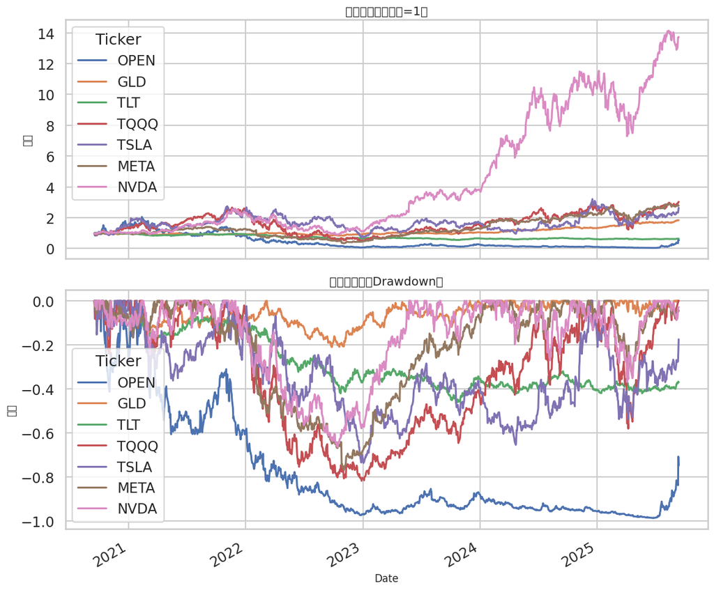

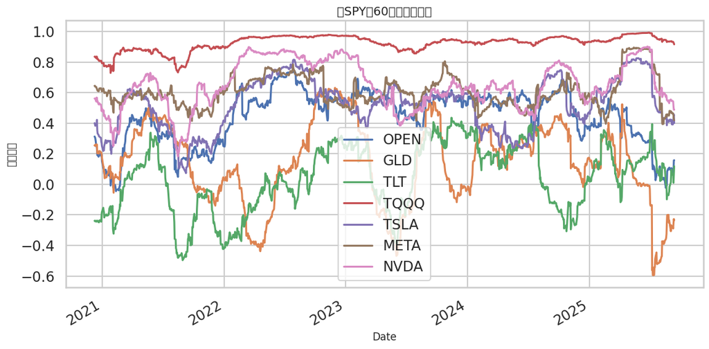

```python
# 其他分析：最大回撤曲线与滚动相关性

# 1) 单资产净值与回撤曲线
asset_nav = (1 + returns).cumprod()
asset_rolling_max = asset_nav.cummax()
asset_drawdown = asset_nav / asset_rolling_max - 1

fig, axes = plt.subplots(2, 1, figsize=(12, 10), sharex=True)
asset_nav.plot(ax=axes[0], title='单资产净值（起始=1）')
axes[0].set_ylabel('净值')
asset_drawdown.plot(ax=axes[1], title='单资产回撤（Drawdown）')
axes[1].set_ylabel('回撤')
plt.tight_layout()
plt.show()

# 2) 滚动相关性（与SPY的60日滚动相关）
rolling_corr = pd.DataFrame(index=returns.index, columns=TICKERS_VALID)
for col in TICKERS_VALID:
    rolling_corr[col] = returns[col].rolling(60).corr(benchmark_returns.reindex(returns.index))

ax = rolling_corr.plot(title='与SPY的60日滚动相关性')
ax.set_ylabel('相关系数')
plt.tight_layout()
plt.show()
```

```python
# 图表导出（可选）：将关键图表与表格保存到 /workspace/outputs 目录
# 说明：在交互式环境中图表已内联显示，这里再存为文件以便报告复用

import os
os.makedirs('/workspace/outputs', exist_ok=True)

# 示例：保存净值图
ax = portfolio_nav.plot(title='策略净值对比（起始=1）')
ax.set_ylabel('净值')
plt.tight_layout()
plt.savefig('/workspace/outputs/strategy_nav.png', dpi=150)
plt.close()

# 保存夏普比率柱状图
plt.figure(figsize=(10,6))
sharpe.sort_values(ascending=False).plot(kind='bar', color='teal', title='夏普比率（年化）')
plt.ylabel('Sharpe Ratio')
plt.tight_layout()
plt.savefig('/workspace/outputs/sharpe_bar.png', dpi=150)
plt.close()

# 保存相关性矩阵csv已在前面完成
# 可选保存载荷矩阵
loadings.to_csv('/workspace/outputs/pca_loadings.csv')

# 保存策略绩效表
perf_df.round(3).to_csv('/workspace/outputs/strategy_performance.csv')
print('图表与表格已导出到 /workspace/outputs')
```

```
图表与表格已导出到 /workspace/outputs
```